Ir al contenido

Ficha actualizada el 12 nov 2026

Ficha del establecimiento · RBD 9720

# Colegio Hernán Olguín

Lo EspejoEscuela BásicaCon Programa de Integración EscolarJornada escolar completa

Álex Ramon Alvarez Muñoz

Dirección del establecimiento

🎒Matrícula

379

−72 respecto de 2025

📅Asistencia promedio

77,6 %

5,2 puntos bajo el promedio del SLEP

📇Estudiantes prioritarios

73,2 %

Concentración declarada (marzo)

📊SIMCE Lectura 4° básico

245 pts

−13 pts respecto del SLEP

¿Primera vez leyendo una ficha?Empieza por la ficha en cifras[Guía para leer los datos (se abre en otra pestaña)](https://datos.slepsantarosa.workers.dev/guia.html)

## La ficha en cifras

Cada cifra enlaza a su sección, donde está explicada y comparada con el SLEP.

📇Estudiantes prioritarios73,2 %Concentración declarada (marzo)Ver sección: Estudiantes prioritarios →

🎒Matrícula379−72 respecto de 2025Ver sección: Matrícula →

📅Asistencia promedio77,6 %5,2 puntos bajo el promedio del SLEPVer sección: Asistencia promedio →

🪑Ocupación de cursos54,9 %379 de 690 cupos declaradosVer sección: Ocupación de cursos →

🤝Estudiantes en el PIE10527,7 % de la matrículaVer sección: Estudiantes en el PIE →

🚶Retiros en 20265815,3 % de la matrículaVer sección: Retiros en 2026 →

📗Aprobación100,0 %Año escolar 2025Ver sección: Aprobación →

📊SIMCE Lectura 4° básico245 pts−13 pts respecto del SLEPVer sección: SIMCE Lectura 4° básico →

🏷️Categoría de desempeñoInsuficienteEducación básica · 2019Ver sección: Categoría de desempeño →

💛Clima de convivencia escolar67,0De 0 a 100 · 2025Ver sección: Clima de convivencia escolar →

🧭Lectura en Nivel III del DIA19,0 %El nivel más alto · monitoreo intermedio 2026 · 248 evaluadosVer sección: Lectura en Nivel III del DIA →

👥Funcionarios8447 docentes y 37 asistentes de la educaciónVer sección: Funcionarios →

📈Docentes en tramo avanzado o superior53 %25 de 47 docentesVer sección: Docentes en tramo avanzado o superior →

📜Acciones del plan de mejoramiento17Plan 2025, en 4 dimensionesVer sección: Acciones del plan de mejoramiento →

⭐SNED 2026-2027No seleccionadoÍndice de 61,4 sobre 100Ver sección: SNED 2026-2027 →

🔗Convenios de uso de espacios6Organizaciones que usan sus espaciosVer sección: Convenios de uso de espacios →

🛡️Denuncias registradas2Última en 2025Ver sección: Denuncias registradas →

🗺️Niños y jóvenes en el barrio6.668De 0 a 17 años, a 800 m a la redondaVer sección: Niños y jóvenes en el barrio →

📍Estudiantes de la misma comuna83 %Viven en Lo Espejo, la comuna del establecimientoVer sección: Estudiantes de la misma comuna →

Capítulo

¿Qué establecimiento es y qué ofrece?

## 🏫El establecimiento

- 📇Identificación y contacto
- 🎭Vida escolar y participación

El establecimiento · Identificación y contactoDatos al 16 oct 2026

### 📇Identificación y contacto

¿Qué establecimiento es y cómo contactarlo?

Escuela Básica en funcionamiento en Lo Espejo, imparte enseñanza básica, educación parvularia y atiende a 379 estudiantes.

[figure not shown]

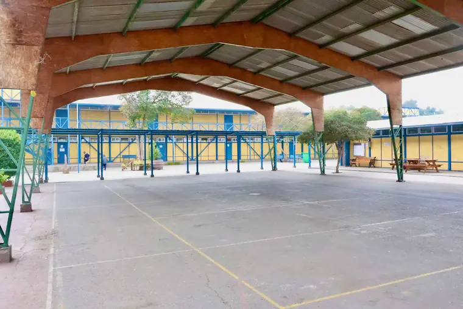

[figure not shown]

📷Fotografías del establecimiento

Concentración de estudiantes prioritarios

73,2 %

Estudiantes cuya situación socioeconómica puede afectar su rendimiento, según el Ministerio de Educación.

Índice de vulnerabilidad (IVE)

96,4 %

Su comuna: 88,5 %. Lo calcula la JUNAEB y decide a qué establecimientos llegan primero los programas de apoyo.

Cursos en funcionamiento

En enseñanza básica y educación parvularia

Programas y convenios

2

Programa de Integración Escolar · Jornada Escolar Completa

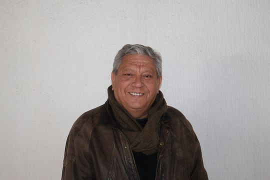

👤Dirección del establecimiento

Álex Ramon Alvarez Muñoz

✉️colegiohernanolguin@slepsantarosa.cl

📱Celular: +56 9 7982 8495

☎️Teléfono del establecimiento: 3144730

🤝Asesoría técnica del SLEP: Diego Jara Asquet · diego.jara@slepsantarosa.gob.cl

📍Dónde queda

Av. Central Cardenal Raúl Silva Henríquez 8108, Lo Espejo.

[interactive chart not shown]

Fuente: Coordenadas del directorio consolidado · [Abrir en Google Maps](https://www.google.com/maps/search/?api=1&query=-33.521875,-70.697029)

#### Identificación

**RBD**

9720-9

**Tipo de establecimiento**

Escuela Básica

**Dependencia**

Servicio Local de Educación Pública Santa Rosa

**Estado**

Funcionando

**Comuna**

Lo Espejo

#### Cómo contactarlo

**Dirección**

Av. Central Cardenal Raúl Silva Henríquez 8108

**Teléfono**

3144730

**Correo**

colegiohernanolguin@slepsantarosa.cl

#### Equipo y apoyo técnico

**Dirección**

Álex Ramon Alvarez Muñoz

**Unidad Técnico Pedagógica**

utp.colegiohernanolguin@slepsantarosa.cl

**Inspectoría**

inspectoria.colegiohernanolguin@slepsantarosa.cl

**Asesoría técnica del SLEP**

Diego Jara Asquet

**Correo de la asesoría**

diego.jara@slepsantarosa.gob.cl

#### Programas y convenios vigentes

Programa de Integración Escolar (PIE)Jornada Escolar CompletaSin PACE

#### Apoyos profesionales al aprendizaje

ReforzamientoPsicopedagogíaPsicologíaProfesor o profesora de educación especialTrabajo socialFonoaudiologíaOtro: Terapeuta ocupacionalOrientaciónOrientación vocacional

#### Necesidades educativas que atiende

Tipos de necesidades educativas especiales que el establecimiento declara atender.

Discapacidad motoraTrastorno del espectro autistaDificultades de aprendizajeTrastorno específico del lenguajeDéficit atencionalFuncionamiento intelectual limítrofe

#### Infraestructura declarada

Biblioteca (CRA)Laboratorio de cienciasSala de usos múltiplesComputación con internetSala audiovisualCancha deportivaGimnasio techadoAccesibilidad para NEE

#### Documentos públicos

[Proyecto Educativo Institucional (PEI)](https://wwwfs.mineduc.cl/Archivos/infoescuelas/documentos/9720/ProyectoEducativo9720.pdf)[Reglamento de convivencia](https://wwwfs.mineduc.cl/Archivos/infoescuelas/documentos/9720/ReglamentodeConvivencia9720.pdf)[Reglamento de evaluación](https://wwwfs.mineduc.cl/Archivos/infoescuelas/documentos/9720/ReglamentoDeEvaluacion9720.pdf)

**¿Cómo se lee este dato?**

**Qué es**

La identificación oficial del establecimiento y las vías para comunicarse con él.

**De dónde sale**

Del directorio consolidado que el equipo actualiza cada mes con el registro oficial del Ministerio de Educación y los datos del propio Servicio Local.

**Cómo leerlo**

El **RBD** es el número con que el Ministerio identifica a cada establecimiento: sirve para buscarlo en cualquier sistema público. **Dependencia** indica quién lo administra; desde el traspaso, es el Servicio Local de Educación Pública.

**Referencia**

La **concentración de estudiantes prioritarios** es el porcentaje de estudiantes cuya situación socioeconómica puede dificultar su trayectoria escolar; el Ministerio la usa para asignar la subvención escolar preferencial.

**Lo que no dice**

Que un establecimiento tenga más programas no significa mejores resultados: son convenios a los que se postula según su proyecto y su matrícula.

**Para saber más**

[Guía para leer los datos: Cómo leer una ficha (se abre en otra pestaña)](https://datos.slepsantarosa.workers.dev/guia.html#empezar)

El establecimiento · Vida escolar y participación

### 🎭Vida escolar y participación

¿Quiénes participan en la comunidad educativa?

El establecimiento tiene centro de padres y apoderados, con personalidad jurídica vencida y cuenta con centro de estudiantes.

Centro de padres

Constituido

Personalidad jurídica: vencida

Centro de estudiantes

Constituido

Lo integran estudiantes del establecimiento

Consejo escolar

Con representante del sostenedor

Osman Yeomans Jiménez

#### Centro de padres y apoderados

**Personalidad jurídica**

Vencida

**Certificado de directorio vigente**

DPJ_HERNAN OLGUIN.pdf

**Última elección del directorio**

**Próxima elección**

Para contactarlo, escribe al establecimiento: sus datos están en «Identificación y contacto».

#### Centro de estudiantes

El establecimiento tiene centro de estudiantes constituido. Lo integran estudiantes del propio establecimiento.

#### Consejo escolar

**Representante del sostenedor**

Osman Yeomans Jiménez

**Acompañamiento del SLEP**

Osman Yeomans Jiménez

**¿Cómo se lee este dato?**

**Qué es**

Las tres instancias de participación que la ley exige a cada establecimiento: el **consejo escolar** (donde se encuentran dirección, docentes, asistentes, apoderados y estudiantes), el **centro de padres** y el **centro de estudiantes**.

**De dónde sale**

Del registro que mantiene el Servicio Local con los establecimientos, actualizado cuando hay elecciones o cambios de directiva.

**Cómo leerlo**

La **personalidad jurídica** permite al centro de padres administrar recursos propios. Un centro sin directorio vigente no puede firmar convenios ni recibir aportes.

**Lo que no dice**

Que una instancia figure constituida no dice cuán activa es: el registro solo guarda su estado formal.

Capítulo

¿A quiénes educa y cómo avanzan durante el año?

## 🧒Estudiantes

- 🎒Matrícula
- 📅Asistencia
- 🪑Ocupación de cursos
- 🤝Programa de Integración Escolar (PIE)
- 🚶Retiros y traslados

Estudiantes · MatrículaDatos de septiembre de 2026

### 🎒Matrícula

¿Cuántos estudiantes tiene y cómo ha cambiado?

En septiembre de 2026 estudian 379 estudiantes en el establecimiento, 72 menos que en 2025. El 44,6 % son mujeres y el 18,7 % tiene nacionalidad extranjera.

Estudiantes matriculados

379

−72 estudiantes respecto de 2025 (−16,0 %)

82

SLEP 300379

915Rango de los establecimientos del SLEP

Estudiantes por curso

21,1

18 cursos en funcionamiento

10,5

SLEP 23,821,1

39,5Rango de los establecimientos del SLEP

Estudiantes mujeres

44,6 %

169 de 379 estudiantes

0,0 %

SLEP 46,5 %44,6 %

100,0 %Rango de los establecimientos del SLEP

Estudiantes extranjeros

18,7 %

71 de 379 estudiantes

6,5 %

SLEP 29,8 %18,7 %

77,6 %Rango de los establecimientos del SLEP

La matrícula bajó 16,0 % en el último año

Estudiantes matriculados en septiembre de cada año, según el registro mensual del SIGE.

[interactive chart not shown]

Fuente: SIGE, MINEDUC.

#### Género, nacionalidad y origen

Cómo se reparten los 379 estudiantes de septiembre de 2026, según lo que el establecimiento registra de cada uno en el SIGE. Los porcentajes son sobre el total de estudiantes.

#### Por género

- **Mujeres**44,6 % · 169 estudiantes
- **Hombres**55,4 % · 210 estudiantes

#### Por nacionalidad

- **Chilena**81,3 % · 308 estudiantes
- **Extranjera**18,7 % · 71 estudiantes

#### País de origen distinto de Chile

- Venezuela5,8 %22
- Haití2,4 %9
- Otros6,1 %23

#### Pueblo originario

- **Pertenece a un pueblo originario**11,3 % · 43 estudiantes
- **No pertenece**81,0 % · 307 estudiantes
- **Sin registro**7,7 % · 29 estudiantes

Los grupos de menos de 5 estudiantes se suman en «Otros» para no identificar a nadie. País de origen: la tarjeta muestra los países declarados en el registro, sin contar Chile (54 estudiantes). Es un dato distinto de la nacionalidad (71 estudiantes de nacionalidad extranjera) y no siempre coincide con ella: muestra lo que el establecimiento registró, no el total de estudiantes de cada país.

**¿Cómo se lee este dato?**

**Qué es**

La cantidad de estudiantes inscritos en el establecimiento en el mes de corte, y cómo se reparte ese total por género, nacionalidad, país de origen y pueblo originario.

**De dónde sale**

Del Sistema de Información General de Estudiantes (SIGE), que cada establecimiento actualiza mes a mes. El género, la nacionalidad, el país de origen y el pueblo originario son los que el establecimiento registra al matricular a cada estudiante.

**Cómo leerlo**

Mira la tendencia de varios años antes que un mes aislado: la matrícula se mueve todo el año por traslados, retiros y nuevas incorporaciones. En el desglose, los grupos de menos de 5 estudiantes se suman en «Otros» para no identificar a nadie; si aun así no quedan al menos dos grupos, ese desglose no se muestra.

**Lo que no dice**

Que un establecimiento tenga más estudiantes no significa que enseñe mejor: el tamaño depende de la infraestructura, de los cupos declarados y del barrio. En el desglose, una diferencia chica entre dos grupos puede ser un solo estudiante: mira también el número, no solo el porcentaje. La nacionalidad y el país de origen son dos datos distintos del registro y no siempre calzan: un estudiante de nacionalidad extranjera puede figurar con Chile como país de origen. Por eso sus cifras no tienen por qué coincidir.

**Para saber más**

[Guía para leer los datos: Matrícula (se abre en otra pestaña)](https://datos.slepsantarosa.workers.dev/guia.html#matricula)

**Ver la matrícula curso por curso (18 cursos)**

Matrícula por curso

| Curso | Estudiantes | % del total |
| --- | --- | --- |
| Pre-kínder A | 19 | 5,0 % |
| Kínder A | 23 | 6,1 % |
| 1° Básico A | 14 | 3,7 % |
| 1° Básico B | 16 | 4,2 % |
| 2° Básico A | 18 | 4,7 % |
| 2° Básico B | 19 | 5,0 % |
| 3° Básico A | 29 | 7,7 % |
| 3° Básico B | 24 | 6,3 % |
| 4° Básico A | 15 | 4,0 % |
| 4° Básico B | 14 | 3,7 % |
| 5° Básico A | 19 | 5,0 % |
| 5° Básico B | 22 | 5,8 % |
| 6° Básico A | 24 | 6,3 % |
| 6° Básico B | 23 | 6,1 % |
| 7° Básico A | 23 | 6,1 % |
| 7° Básico B | 23 | 6,1 % |
| 8° Básico A | 27 | 7,1 % |
| 8° Básico B | 27 | 7,1 % |

Estudiantes · AsistenciaDatos de septiembre de 2026

### 📅Asistencia

¿Cuántos estudiantes van a clases todos los días?

De marzo a septiembre de 2026, los estudiantes asistieron en promedio 77,6 % de los días con clases: 5,2 puntos bajo el promedio del SLEP (82,8 %). Entre las mujeres la asistencia fue de 77,1 % y entre los hombres, de 78,0 %.

Asistencia promedio del año

77,6 %

−0,3 puntos respecto de 2025

49,4 %

SLEP 82,8 %77,6 %

90,4 %Rango de los establecimientos del SLEP

Asistencia de septiembre

81,0 %

379 estudiantes en 18 cursos

Curso con menor asistencia

70,2 %

6° Básico A · 7,4 puntos bajo el promedio del establecimiento

Ningún mes de 2026 alcanza el 85 %

Asistencia promedio del establecimiento en cada mes de 2026, ponderada por la matrícula de cada curso.

[interactive chart not shown]

Fuente: SIGE, MINEDUC.

#### Asistencia por género, nacionalidad y origen

Asistencia promedio de marzo a septiembre de 2026 de cada grupo, calculada igual que la del establecimiento: ponderada por la cantidad de estudiantes del grupo en cada curso. La raya marca el promedio del establecimiento (77,6 %). Bajo el nombre de cada grupo va su cantidad de estudiantes en septiembre.

#### Por género

- Mujeres169 estudiantes77,1 %
- Hombres210 estudiantes78,0 %

Promedio del establecimiento: **77,6 %**

#### Por nacionalidad

- Chilena308 estudiantes76,5 %
- Extranjera71 estudiantes82,1 %

Promedio del establecimiento: **77,6 %**

#### Por país de origen distinto de Chile

- Venezuela22 estudiantes70,3 %
- Otros32 estudiantes84,8 %

Promedio del establecimiento: **77,6 %**

#### Por pueblo originario

- Pertenece a un pueblo originario43 estudiantes79,8 %
- No pertenece307 estudiantes77,3 %
- Sin registro29 estudiantes76,7 %

Promedio del establecimiento: **77,6 %**

La asistencia de un grupo se publica solo si tuvo 10 o más estudiantes en todos los meses del período, para no identificar a nadie; los grupos más chicos se suman en «Otros». Por país de origen se muestran los países declarados en el registro, sin contar Chile. Es un dato distinto de la nacionalidad y no siempre coincide con ella: las cifras describen solo a quienes tienen ese país registrado, no a todos los estudiantes de cada país.

**¿Cómo se lee este dato?**

**Qué es**

La proporción entre los días que un estudiante va a clases y los días que hubo clases. La asistencia de un curso, de un grupo de estudiantes o de un establecimiento es el promedio de esos porcentajes.

**De dónde sale**

El establecimiento registra la asistencia todos los días y la declara cada mes en el Sistema de Información General de Estudiantes (SIGE). Esa misma asistencia es la base de la subvención.

**Cómo leerlo**

Compara cada mes con el mismo mes del año anterior: marzo y diciembre se leen distinto por el ingreso escalonado y el cierre del año. En el desglose por género, nacionalidad y origen, la asistencia de un grupo se publica solo si tuvo 10 o más estudiantes durante todo el período, para no identificar a nadie.

**Referencia**

El Decreto 67 de 2018 exige al menos 85 % de asistencia en el año para ser promovido, con excepciones que autoriza la dirección. El Centro de Estudios del Ministerio usa cuatro categorías: destacada (97 % o más), normal (90 a 97 %), inasistencia reiterada (85 a 90 %) e inasistencia grave (85 % o menos).

**Lo que no dice**

Cuántos estudiantes faltan mucho. Un promedio alto puede esconder a varios estudiantes bajo el 85 %: para saberlo hay que mirar caso a caso, no el promedio. Tampoco que un grupo falte más que otro por una diferencia de uno o dos puntos: en grupos de menos de 20 estudiantes el promedio cambia mucho con un solo caso, y el dato no dice por qué falta cada estudiante.

**Para saber más**

[Guía para leer los datos: Asistencia (se abre en otra pestaña)](https://datos.slepsantarosa.workers.dev/guia.html#asistencia)

**Ver la asistencia curso por curso (18 cursos)**

Asistencia por curso, marzo a septiembre de 2026

| Curso | Estudiantes | Asistencia del año | Situación |
| --- | --- | --- | --- |
| Pre-kínder A | 21 | 71,1 % | Bajo el umbral |
| Kínder A | 24 | 77,3 % | Bajo el umbral |
| 1° Básico A | 14 | 78,4 % | Bajo el umbral |
| 1° Básico B | 17 | 73,2 % | Bajo el umbral |
| 2° Básico A | 18 | 79,6 % | Bajo el umbral |
| 2° Básico B | 20 | 81,7 % | Bajo el umbral |
| 3° Básico A | 29 | 71,4 % | Bajo el umbral |
| 3° Básico B | 25 | 78,3 % | Bajo el umbral |
| 4° Básico A | 15 | 86,6 % | Sobre el umbral |
| 4° Básico B | 15 | 81,4 % | Bajo el umbral |
| 5° Básico A | 19 | 75,6 % | Bajo el umbral |
| 5° Básico B | 23 | 79,4 % | Bajo el umbral |
| 6° Básico A | 24 | 70,2 % | Bajo el umbral |
| 6° Básico B | 23 | 74,0 % | Bajo el umbral |
| 7° Básico A | 23 | 76,5 % | Bajo el umbral |
| 7° Básico B | 24 | 81,6 % | Bajo el umbral |
| 8° Básico A | 27 | 78,5 % | Bajo el umbral |
| 8° Básico B | 26 | 85,6 % | Sobre el umbral |

Estudiantes · Ocupación de cursosDatos de septiembre de 2026

### 🪑Ocupación de cursos

¿Cuántos cupos están ocupados en cada curso?

En septiembre de 2026, 379 estudiantes ocupan los 690 cupos que el establecimiento declaró al Sistema de Admisión Escolar (SAE): 54,9 % de ocupación, con 311 cupos disponibles.

Ocupación de los cupos declarados

54,9 %

379 estudiantes en 690 cupos

33,3 %

SLEP 68,3 %54,9 %

111,2 %Rango de los establecimientos del SLEP

Cursos sobre su capacidad declarada

0

de 18 cursos con cupos declarados

Cupos disponibles

311

repartidos en 18 cursos

Quedan 311 cupos disponibles, repartidos en 18 cursos

Estudiantes matriculados en septiembre de 2026 (barra azul) sobre los cupos que el establecimiento declaró al SAE (barra gris).

[interactive chart not shown]

Fuente: SIGE y Sistema de Admisión Escolar, MINEDUC.

**¿Cómo se lee este dato?**

**Qué es**

La ocupación compara los estudiantes efectivamente matriculados en cada curso con los cupos que el establecimiento declaró al Sistema de Admisión Escolar (SAE).

**De dónde sale**

Los cupos los declara el propio establecimiento en el proceso del SAE; la matrícula sale del registro mensual del SIGE. Las dos cifras viajan en la misma tabla, curso por curso.

**Cómo leerlo**

El 100 % significa que todos los cupos declarados están tomados. Pasar del 100 % quiere decir que hay más estudiantes que cupos: casi siempre es señal de que la capacidad declarada al SAE quedó desactualizada, no de que sobren estudiantes en la sala.

**Referencia**

No hay un umbral oficial: la referencia es la capacidad declarada (100 %). Entre los 53 establecimientos del SLEP que declaran cupos, la ocupación va de 33,3 % a 111,2 %, con un promedio de 68,3 %.

**Lo que no dice**

Cuánto espacio físico real tiene el establecimiento. Un curso puede aparecer con cupos libres porque se reservaron vacantes para el SAE o porque la capacidad declarada es mayor que la que se usa.

**Para saber más**

[Guía para leer los datos: Matrícula (se abre en otra pestaña)](https://datos.slepsantarosa.workers.dev/guia.html#matricula)

**Ver los cupos curso por curso (18 cursos)**

Cupos declarados y matrícula por curso, septiembre de 2026

| Curso | Estudiantes | Cupos declarados | Ocupación | Cupos disponibles |
| --- | --- | --- | --- | --- |
| Pre-kínder A | 19 | 25 | 76,0 % | 6 |
| Kínder A | 23 | 25 | 92,0 % | 2 |
| 1° Básico A | 14 | 40 | 35,0 % | 26 |
| 1° Básico B | 16 | 40 | 40,0 % | 24 |
| 2° Básico A | 18 | 40 | 45,0 % | 22 |
| 2° Básico B | 19 | 40 | 47,5 % | 21 |
| 3° Básico A | 29 | 40 | 72,5 % | 11 |
| 3° Básico B | 24 | 40 | 60,0 % | 16 |
| 4° Básico A | 15 | 40 | 37,5 % | 25 |
| 4° Básico B | 14 | 40 | 35,0 % | 26 |
| 5° Básico A | 19 | 40 | 47,5 % | 21 |
| 5° Básico B | 22 | 40 | 55,0 % | 18 |
| 6° Básico A | 24 | 40 | 60,0 % | 16 |
| 6° Básico B | 23 | 40 | 57,5 % | 17 |
| 7° Básico A | 23 | 40 | 57,5 % | 17 |
| 7° Básico B | 23 | 40 | 57,5 % | 17 |
| 8° Básico A | 27 | 40 | 67,5 % | 13 |
| 8° Básico B | 27 | 40 | 67,5 % | 13 |

Estudiantes · PIEDatos de abril de 2026

### 🤝Programa de Integración Escolar (PIE)

¿Cuántos estudiantes reciben apoyos del Programa de Integración Escolar?

105 estudiantes reciben apoyos del Programa de Integración Escolar: 27,7 % de la matrícula, 8,9 puntos sobre el promedio del SLEP (18,8 %).

Estudiantes en el PIE

105

de 379 estudiantes matriculados en septiembre de 2026

3

SLEP 53105

140Rango de los establecimientos del SLEP

Porcentaje de la matrícula

27,7 %

+8,9 puntos respecto del promedio del SLEP (18,8 %)

1,7 %

SLEP 18,8 %27,7 %

34,2 %Rango de los establecimientos del SLEP

Diagnóstico más frecuente

35estudiantes

Lenguaje (TEL) · 33 % de quienes están en el PIE

El PIE bajó de 145 a 125 estudiantes entre 2024 y 2026

Estudiantes con necesidades educativas especiales registrados cada año por el Área de Inclusión Educativa del SLEP. Es un catastro distinto de la nómina del SIGE que alimenta las cifras clave, por eso los totales no coinciden exactamente.

[interactive chart not shown]

Fuente: PIE Territorial, Área de Inclusión Educativa del SLEP Santa Rosa.

#### Quiénes reciben los apoyos

Los 105 estudiantes del programa en abril de 2026, según la nómina del SIGE. Cada tarjeta mira una sola característica.

#### Por tipo de necesidad

- **Necesidad permanente**25,7 % · 27 estudiantes
- **Necesidad transitoria**74,3 % · 78 estudiantes

#### Por género

- **Mujeres**39,0 % · 41 estudiantes
- **Hombres**61,0 % · 64 estudiantes

#### Por nivel de enseñanza

- Educación parvularia7 %7
- Educación básica93 %98

#### Por nacionalidad

- **Chilena**92,4 % · 97 estudiantes
- **Extranjera**7,6 % · 8 estudiantes

**¿Cómo se lee este dato?**

**Qué es**

El Programa de Integración Escolar (PIE) entrega apoyos adicionales —profesionales de apoyo, horas de trabajo conjunto con los docentes y materiales— a los estudiantes que tienen una necesidad educativa especial (NEE) diagnosticada, dentro de la misma sala de clases.

**De dónde sale**

El detalle por estudiante sale de la nómina PIE del SIGE (abril de 2026) y la serie por año, del catastro del Área de Inclusión Educativa del SLEP. Son dos registros distintos, con fechas distintas: sus totales no calzan exactamente.

**Cómo leerlo**

Una necesidad «permanente» acompaña a la persona durante toda su vida —por ejemplo una discapacidad intelectual, sensorial o motora— y da derecho a apoyos en toda la trayectoria escolar. Una necesidad «transitoria» se presenta en un período de la escolaridad y se espera que se supere con apoyo, como las dificultades del aprendizaje o del lenguaje. En la mayoría de los establecimientos las transitorias son las más numerosas.

**Referencia**

En el SLEP Santa Rosa el promedio es 18,8 % de la matrícula. El programa se rige por el Decreto 170 del Ministerio de Educación, que define qué diagnósticos puede atender y qué apoyos financia.

**Lo que no dice**

Un porcentaje alto de estudiantes en el PIE no es un mal resultado: habla de cuántos estudiantes tienen apoyos reconocidos y financiados, no de cómo enseña el establecimiento. Tampoco dice cuántos estudiantes necesitan apoyo, porque solo cuenta a quienes ya tienen un diagnóstico vigente y entraron al programa. Por lo mismo, las diferencias por género, nivel o nacionalidad muestran a quiénes se ha diagnosticado, no quiénes necesitan más apoyo. Los grupos de menos de 5 estudiantes se suman en «Otros» para no identificar a nadie, y con menos de 5 estudiantes en el programa no se muestra ningún desglose.

**Ver el detalle por diagnóstico**

Estudiantes del PIE por diagnóstico

| Diagnóstico | Tipo de necesidad | Estudiantes | % del PIE |
| --- | --- | --- | --- |
| Lenguaje (TEL) | Transitoria | 35 | 33,3 % |
| Dificultades del aprendizaje | Transitoria | 26 | 24,8 % |
| Discapacidad intelectual | Permanente | 21 | 20,0 % |
| Funcionamiento limítrofe | Transitoria | 17 | 16,2 % |
| Espectro autista (TEA) | Permanente | 6 | 5,7 % |

Estudiantes · Retiros y trasladosDatos de septiembre de 2026

### 🚶Retiros y traslados

¿Cuántos estudiantes se fueron durante el año y por qué?

En 2026 se registraron 58 retiros: 15,3 % de la matrícula, 1,6 puntos sobre el promedio del SLEP (13,7 %).

De los 58 retiros de 2026, 7 son cambios de curso dentro del mismo establecimiento: el SIGE los anota como un retiro y una matrícula nueva, aunque el estudiante nunca se fue. Estudiantes que efectivamente dejaron el establecimiento: 51.

Retiros registrados en 2026

58

−6 respecto del mismo período de 2025 (64 retiros)

1

SLEP 3958

155Rango de los establecimientos del SLEP

Porcentaje de la matrícula

15,3 %

+1,6 puntos respecto del promedio del SLEP (13,7 %)

0,6 %

SLEP 13,7 %15,3 %

103,3 %Rango de los establecimientos del SLEP

Dejaron el establecimiento

51estudiantes

39 siguieron en otro establecimiento y 12 quedaron sin matrícula posterior

Abril concentró la mayor cantidad de retiros: 14 de 58

Retiros registrados cada mes de 2026, desde marzo hasta septiembre.

[interactive chart not shown]

Fuente: Registro de retiros y traslados del SIGE, MINEDUC.

#### Quiénes dejaron el establecimiento

51 estudiantes dejaron el establecimiento en 2026. No se cuentan los cambios de curso internos y cada estudiante aparece una vez, por su último movimiento del año. La comuna de destino se conoce para los 39 que se matricularon en otro establecimiento.

#### Por género

- **Mujeres**45,1 % · 23 estudiantes
- **Hombres**54,9 % · 28 estudiantes

#### Por nacionalidad

- **Chilena**68,6 % · 35 estudiantes
- **Extranjera**31,4 % · 16 estudiantes

#### Por nivel de enseñanza

- Educación parvularia16 %8
- Educación básica84 %43

#### Por comuna de destino

- Lo Espejo41 %16
- Pedro Aguirre Cerda26 %10
- San Bernardo13 %5
- Otras comunas21 %8

Los grupos de menos de 5 estudiantes se suman en «Otros» para no identificar a nadie.

**¿Cómo se lee este dato?**

**Qué es**

Un retiro es el registro que hace el establecimiento en el SIGE cuando un estudiante deja su curso durante el año escolar. No todos los retiros son iguales: la mayoría son traslados, es decir, el estudiante se matricula en otro establecimiento y sigue estudiando.

**De dónde sale**

Del registro de retiros y traslados del SIGE, cruzado con la matrícula vigente para saber dónde quedó cada estudiante. El corte de estos datos es septiembre de 2026.

**Cómo leerlo**

Distingue el «traslado a otro establecimiento» —el estudiante sigue en el sistema escolar, dentro o fuera del SLEP— del «retiro sin matrícula posterior», que es el que conviene mirar de cerca, porque puede anticipar una desvinculación del sistema. Los meses de marzo y diciembre concentran movimientos administrativos —regularizaciones de inicio de año y cierres de curso—, así que un alza en esos meses no significa lo mismo que un alza en mitad del año. Los desgloses por género, nacionalidad, nivel y destino cuentan estudiantes, no movimientos, y dejan fuera los cambios de curso internos.

**Referencia**

En el SLEP Santa Rosa los retiros equivalen en promedio a 13,7 % de la matrícula en lo que va de 2026. La comparación se hace con el mismo corte para todos los establecimientos.

**Lo que no dice**

El retiro no es lo mismo que la deserción: solo la matrícula del año siguiente confirma si un estudiante dejó de estudiar. Y como el año todavía no termina, la cifra seguirá subiendo hasta diciembre: no se puede comparar con el total de un año cerrado. Los desgloses tampoco dicen por qué se fue cada estudiante, y con tan pocos casos una diferencia entre grupos puede ser casualidad. Los grupos de menos de 5 estudiantes se suman en «Otros» para no identificar a nadie.

**Para saber más**

[Guía para leer los datos: Matrícula (se abre en otra pestaña)](https://datos.slepsantarosa.workers.dev/guia.html#matricula)

**Ver el detalle mes a mes**

Retiros de 2026 por mes

| Mes del retiro | Retiros |
| --- | --- |
| Marzo | 12 |
| Abril | 14 |
| Mayo | 6 |
| Junio | 10 |
| Julio | 9 |
| Agosto | 5 |
| Septiembre | 2 |
| Total | 58 |

Capítulo

¿Qué están aprendiendo sus estudiantes?

## 📚Aprendizajes

- 📗Rendimiento
- 📊SIMCE
- 🏷️Categoría de desempeño
- 💛Desarrollo personal y social
- 🧭Diagnóstico Integral de Aprendizajes (DIA)

Aprendizajes · RendimientoDatos de año escolar 2025

### 📗Rendimiento

¿Cuántos estudiantes aprobaron el año?

En 2025, 100,0 % de los estudiantes que terminaron el año fue promovido de curso, 3,5 puntos sobre el promedio del SLEP.

Estudiantes promovidos

100,0 %

0,0 puntos respecto de 2024

49,7 %

SLEP 96,5 %100,0 %

100,0 %Rango de los establecimientos del SLEP

Nota promedio del establecimiento

6,1

Promedio general de 403 estudiantes con nota final

5,4

SLEP 5,96,1

6,3Rango de los establecimientos del SLEP

Reprobados por inasistencia

0

De 0 estudiantes reprobados en 2025

La aprobación se mantiene estable

Porcentaje de estudiantes promovidos sobre los que terminaron el año en el establecimiento (no incluye retirados ni trasladados).

Promedio del SLEP en 2025: 96,5 %

[interactive chart not shown]

Fuente: Actas de rendimiento, SIGE.

#### Aprobación y notas por género y nacionalidad

Resultados de 2025 de quienes terminaron el año, mirando una característica a la vez. La raya marca el valor de todo el establecimiento.

#### Aprobación por género

- Mujeres183 estudiantes100,0 %
- Hombres220 estudiantes100,0 %

Aprobación del establecimiento: **100,0 %**

#### Nota promedio por género

- Mujeres183 con nota final6,1
- Hombres220 con nota final6,0

Nota del establecimiento: **6,1**

#### Aprobación por nacionalidad

- Chilena331 estudiantes100,0 %
- Extranjera72 estudiantes100,0 %

Aprobación del establecimiento: **100,0 %**

#### Nota promedio por nacionalidad

- Chilena331 con nota final6,1
- Extranjera72 con nota final6,0

Nota del establecimiento: **6,1**

**¿Cómo se lee este dato?**

**Qué es**

El resultado del año escolar de cada estudiante: promovido al curso siguiente o reprobado.

**De dónde sale**

De las actas de rendimiento que el establecimiento entrega al Ministerio al cerrar el año, a través del SIGE.

**Cómo leerlo**

La aprobación se calcula sobre quienes **terminaron el año** en el establecimiento. Los estudiantes **retirados** o **trasladados** se cuentan aparte (sección Retiros y traslados), porque su resultado final lo registra otro establecimiento. La nota promedio es el promedio general de cada estudiante con nota final, no un promedio de cursos.

**Referencia**

Un estudiante puede reprobar por notas o por asistencia inferior al 85 % sin justificación aceptada por la dirección.

**Lo que no dice**

Una aprobación de 100 % no significa por sí sola que todos aprendieron lo esperado: para eso están los resultados del SIMCE y del DIA. Las diferencias por género, nacionalidad o curso tampoco explican su causa, y en grupos chicos un solo estudiante mueve varios puntos: por eso las tasas y los promedios solo se muestran para grupos de 10 o más estudiantes, y los más chicos se suman en «Otros» para no identificar a nadie.

**Para saber más**

[Guía para leer los datos: Rendimiento (se abre en otra pestaña)](https://datos.slepsantarosa.workers.dev/guia.html#rendimiento)

**Ver el detalle por curso**

Rendimiento por curso

| Curso | Evaluados | Aprobación | Nota promedio |
| --- | --- | --- | --- |
| 1° Básico | 44 | 100,0 % | 6,2 |
| 2° Básico | 57 | 100,0 % | 6,3 |
| 3° Básico | 36 | 100,0 % | 6,2 |
| 4° Básico | 46 | 100,0 % | 5,9 |
| 5° Básico | 47 | 100,0 % | 5,9 |
| 6° Básico | 55 | 100,0 % | 6,0 |
| 7° Básico | 55 | 100,0 % | 5,9 |
| 8° Básico | 63 | 100,0 % | 6,0 |

Aprendizajes · SIMCEDatos de 2025

### 📊SIMCE

¿Cómo les fue en las pruebas nacionales SIMCE?

En 2025, 4° básico obtuvo 245 pts en Lectura, 13 puntos por debajo de el promedio del SLEP.

Lectura · 4° básico

245 pts

+4 pts respecto de 2024

200

SLEP 258245

314Rango de los establecimientos del SLEP

Matemática · 4° básico

236 pts

−1 pts respecto de 2024

199

SLEP 241236

290Rango de los establecimientos del SLEP

Lectura · 8° básico

205 pts

−8 pts respecto de 2019

175

SLEP 217205

258Rango de los establecimientos del SLEP

Evolución de los puntajes en 4° básico

Puntaje promedio del establecimiento en cada aplicación del SIMCE. No hubo SIMCE en 2020 ni 2021.

[interactive chart not shown]

Fuente: Agencia de Calidad de la Educación.

Para 2025 la Agencia de Calidad publicó los puntajes pero no cuántos estudiantes rindieron la prueba en este establecimiento. Por eso los promedios del SLEP de ese año son simples, no ponderados por matrícula evaluada.

**¿Cómo se lee este dato?**

**Qué es**

El SIMCE es la prueba nacional que aplica la Agencia de Calidad para saber qué aprendieron los estudiantes en Lectura, Matemática y, en algunos años, Ciencias.

**De dónde sale**

De los resultados oficiales que publica la Agencia de Calidad de la Educación por establecimiento y grado.

**Cómo leerlo**

Un puntaje aislado dice poco: compáralo con el promedio del SLEP (la barra de cada tarjeta) y con los años anteriores del mismo curso. Los estándares —**Insuficiente**, **Elemental** y **Adecuado**— dicen cuántos estudiantes alcanzaron lo esperado, que suele ser más informativo que el promedio.

**Referencia**

Diferencias menores a 5 puntos entre años no son significativas: dependen de qué estudiantes rindieron la prueba ese año.

**Lo que no dice**

El SIMCE no mide todo lo que hace una escuela: no evalúa artes, deportes, convivencia ni el progreso individual de cada estudiante.

**Para saber más**

[Guía para leer los datos: SIMCE (se abre en otra pestaña)](https://datos.slepsantarosa.workers.dev/guia.html#simce)

**Ver todos los resultados**

Resultados SIMCE por año, curso y asignatura

| Año | Curso | Asignatura | Puntaje | Evaluados |
| --- | --- | --- | --- | --- |
| 2025 | 4° básico | Lectura | 245 | sin dato |
| 2025 | 4° básico | Matemática | 236 | sin dato |
| 2025 | 8° básico | Lectura | 205 | sin dato |
| 2025 | 8° básico | Matemática | 216 | sin dato |
| 2024 | 4° básico | Lectura | 241 | 35 |
| 2024 | 4° básico | Matemática | 237 | 34 |
| 2024 | 6° básico | Lectura | 221 | 42 |
| 2024 | 6° básico | Matemática | 218 | 41 |
| 2023 | 4° básico | Lectura | 227 | 43 |
| 2023 | 4° básico | Matemática | 211 | 45 |
| 2022 | 4° básico | Lectura | 246 | 48 |
| 2022 | 4° básico | Matemática | 221 | 50 |
| 2019 | 8° básico | Historia y Ciencias Sociales | 215 | 71 |
| 2019 | 8° básico | Lectura | 213 | 65 |
| 2019 | 8° básico | Matemática | 221 | 67 |
| 2018 | 4° básico | Lectura | 257 | 85 |
| 2018 | 4° básico | Matemática | 223 | 87 |
| 2018 | 6° básico | Ciencias Naturales | 191 | 64 |
| 2018 | 6° básico | Lectura | 199 | 64 |
| 2018 | 6° básico | Matemática | 198 | 63 |
| 2017 | 4° básico | Lectura | 239 | 66 |
| 2017 | 4° básico | Matemática | 222 | 62 |
| 2016 | 4° básico | Lectura | 215 | 69 |
| 2016 | 4° básico | Matemática | 217 | 72 |
| 2016 | 6° básico | Historia y Ciencias Sociales | 211 | 74 |
| 2016 | 6° básico | Lectura | 212 | 74 |
| 2016 | 6° básico | Matemática | 213 | 74 |

Aprendizajes · Categoría de desempeñoDatos de 2019

### 🏷️Categoría de desempeño

¿Cómo clasifica la Agencia de Calidad a este establecimiento?

En 2019 la Agencia de Calidad clasificó al establecimiento como Insuficiente en educación básica.

La Agencia de Calidad ordena a todos los establecimientos del país en cuatro categorías. No mira solo el SIMCE: combina los puntajes con los indicadores de desarrollo personal y social, con el contexto socioeconómico de los estudiantes y con cuánto avanzó el establecimiento respecto de sí mismo. La categoría define qué apoyo recibe del Estado.

Educación básica

Insuficiente

En 2018 era insuficiente.

Cómo ha cambiado la clasificación

Categoría asignada en cada año con clasificación publicada. El color del punto repite la categoría: verde Alto, azul Medio, amarillo Medio-bajo, rojo Insuficiente.

[interactive chart not shown]

Fuente: Agencia de Calidad de la Educación.

#### El historial completo

Categoría de desempeño por año y nivel

| Año | Nivel | Categoría |
| --- | --- | --- |
| 2019 | Básica | Insuficiente |
| 2018 | Básica | Insuficiente |
| 2017 | Básica | Insuficiente |
| 2016 | Básica | Insuficiente |

La última clasificación en las bases del equipo es de 2019. Mientras la Agencia no publique una nueva, esa sigue siendo la categoría vigente del establecimiento.

**¿Cómo se lee este dato?**

**Qué es**

La clasificación oficial que la Agencia de Calidad hace de cada establecimiento del país, una vez al año.

**De dónde sale**

De las ordenaciones que publica la Agencia de Calidad de la Educación, por establecimiento y nivel de enseñanza.

**Cómo leerlo**

Las cuatro categorías, de mayor a menor, son **Alto**, **Medio**, **Medio-bajo** e **Insuficiente**. Se comparan establecimientos de contexto socioeconómico parecido, así que la categoría no es lo mismo que el puntaje SIMCE: una escuela puede tener puntajes bajos y aun así quedar en Medio si avanza más que las escuelas con las que se la compara.

**Referencia**

Las categorías **Medio-bajo** e **Insuficiente** obligan a la Agencia a acompañar al establecimiento con apoyo técnico. Mantenerse en Insuficiente durante cuatro años seguidos puede terminar en la pérdida del reconocimiento oficial.

**Lo que no dice**

La categoría no mide el trabajo de un profesor ni de un curso: es del establecimiento completo y se calcula con datos de varios años, así que refleja una trayectoria, no el año en curso.

**Para saber más**

[Guía para leer los datos: Categoría de Desempeño (se abre en otra pestaña)](https://datos.slepsantarosa.workers.dev/guia.html#categoria-desempeno)

Aprendizajes · Desarrollo personal y socialDatos de 2025

### 💛Desarrollo personal y social

¿Cómo se sienten los estudiantes en su establecimiento?

Entre 2016 y 2025 la Agencia midió estos indicadores 8 veces. El mayor cambio de la última fue participación y formación ciudadana, que bajó 4,5 puntos respecto de 2024 (de 74,0 a 69,5 de 100).

Autoestima académica y motivación escolar

72,0de 100

Igual que en 2024

Bajo el contexto similar

Clima de convivencia escolar

67,0de 100

Igual que en 2024

Bajo el contexto similar

Participación y formación ciudadana

69,5de 100

4,5 puntos menos que en 2024

Bajo el contexto similar

Hábitos de vida saludable

67,0de 100

1,0 punto más que en 2024

Bajo el contexto similar

Cómo cambió cada indicador entre 2016 y 2025

Puntaje promedio del establecimiento en cada aplicación, de 0 a 100. Años con datos: 2016, 2017, 2018, 2019, 2022, 2023, 2024 y 2025. No hubo medición en 2020 y 2021. El eje vertical va de 60 a 80 puntos, no parte en cero, para que se vea el movimiento.

[interactive chart not shown]

Fuente: Agencia de Calidad de la Educación · cuestionarios SIMCE.

En 2025, lo más alto fue autoestima académica y motivación escolar y lo más bajo, hábitos de vida saludable

Puntaje de 0 a 100. La barra azul es el establecimiento; la gris, el promedio de los establecimientos de contexto socioeconómico similar que usa la Agencia para comparar. En 2025 quedó sobre ese promedio en 0 de los 4 indicadores y bajo en 4.

[interactive chart not shown]

Fuente: Agencia de Calidad de la Educación · cuestionarios SIMCE.

**¿Cómo se lee este dato?**

**Qué es**

Cuatro indicadores que miden cómo viven los estudiantes su escuela: autoestima académica y motivación, clima de convivencia, participación y formación ciudadana, y hábitos de vida saludable.

**De dónde sale**

De los cuestionarios que responden estudiantes, familias y docentes junto con el SIMCE. Los calcula la Agencia de Calidad.

**Cómo leerlo**

Van de 0 a 100 y no son notas: 100 sería que todas las respuestas apuntan en la dirección deseada. En el gráfico de evolución, cada línea es un indicador y su color lo identifica; el eje vertical está recortado al rango de los datos para que el movimiento se vea, y se corta en los años sin aplicación. En el gráfico del último año el color dice quién es, no si el resultado es bueno: azul el establecimiento, gris el promedio de establecimientos de contexto socioeconómico similar; la etiqueta de cada tarjeta dice con palabras si el establecimiento quedó sobre, bajo o igual que ese promedio, y una diferencia menor a medio punto se lee como «igual». En 2025 se evaluó más de un curso, así que el puntaje es el promedio de esos cursos y por eso lleva un decimal.

**Referencia**

Estos indicadores pesan un tercio de la Categoría de Desempeño que asigna la Agencia de Calidad. La comparación con establecimientos de contexto similar viene en las bases de 2024 y 2025.

**Lo que no dice**

No miden la convivencia del año en curso: reflejan lo que respondieron las personas el año de la evaluación. Tampoco son un seguimiento de los mismos estudiantes: cada aplicación mide a los cursos que rindieron el SIMCE ese año, que no siempre son los mismos, así que parte del cambio entre años viene de qué cursos se evaluaron.

**Para saber más**

[Guía para leer los datos: Categoría de Desempeño (se abre en otra pestaña)](https://datos.slepsantarosa.workers.dev/guia.html#categoria-desempeno)

**Ver el detalle por año y curso**

Indicadores de desarrollo personal y social

| Año | Curso | Indicador | Puntaje | Contexto similar | Diferencia |
| --- | --- | --- | --- | --- | --- |
| 2025 | 4b | Autoestima académica y motivación escolar | 72,0 | 76,0 | −4 |
| 2025 | 8b | Autoestima académica y motivación escolar | 72,0 | 76,0 | −4 |
| 2025 | 4b | Clima de convivencia escolar | 65,0 | 76,0 | −11 |
| 2025 | 8b | Clima de convivencia escolar | 69,0 | 76,0 | −7 |
| 2025 | 4b | Participación y formación ciudadana | 69,0 | 80,0 | −11 |
| 2025 | 8b | Participación y formación ciudadana | 70,0 | 79,0 | −9 |
| 2025 | 4b | Hábitos de vida saludable | 68,0 | 71,0 | −3 |
| 2025 | 8b | Hábitos de vida saludable | 66,0 | 73,0 | −7 |
| 2024 | 4b | Autoestima académica y motivación escolar | 72,0 | 76,0 | −4 |
| 2024 | 4b | Clima de convivencia escolar | 67,0 | 75,0 | −8 |
| 2024 | 4b | Participación y formación ciudadana | 74,0 | 79,0 | −5 |
| 2024 | 4b | Hábitos de vida saludable | 66,0 | 70,0 | −4 |
| 2023 | 4b | Autoestima académica y motivación escolar | 71,0 | — | — |
| 2023 | 4b | Clima de convivencia escolar | 67,0 | — | — |
| 2023 | 4b | Participación y formación ciudadana | 71,0 | — | — |
| 2023 | 4b | Hábitos de vida saludable | 62,0 | — | — |
| 2022 | 4b | Autoestima académica y motivación escolar | 75,0 | — | — |
| 2022 | 4b | Clima de convivencia escolar | 74,0 | — | — |
| 2022 | 4b | Participación y formación ciudadana | 78,0 | — | — |
| 2022 | 4b | Hábitos de vida saludable | 69,0 | — | — |
| 2019 | 8b | Autoestima académica y motivación escolar | 75,9 | — | — |
| 2019 | 8b | Clima de convivencia escolar | 68,6 | — | — |
| 2019 | 8b | Participación y formación ciudadana | 72,8 | — | — |
| 2019 | 8b | Hábitos de vida saludable | 64,1 | — | — |
| 2018 | 4b | Autoestima académica y motivación escolar | 77,6 | — | — |
| 2018 | 6b | Autoestima académica y motivación escolar | 69,9 | — | — |
| 2018 | 4b | Clima de convivencia escolar | 71,0 | — | — |
| 2018 | 6b | Clima de convivencia escolar | 66,7 | — | — |
| 2018 | 4b | Participación y formación ciudadana | 75,6 | — | — |
| 2018 | 6b | Participación y formación ciudadana | 69,9 | — | — |
| 2018 | 4b | Hábitos de vida saludable | 67,5 | — | — |
| 2018 | 6b | Hábitos de vida saludable | 59,4 | — | — |
| 2017 | 4b | Autoestima académica y motivación escolar | 74,3 | — | — |
| 2017 | 8b | Autoestima académica y motivación escolar | 73,7 | — | — |
| 2017 | 4b | Clima de convivencia escolar | 66,1 | — | — |
| 2017 | 8b | Clima de convivencia escolar | 69,5 | — | — |
| 2017 | 4b | Participación y formación ciudadana | 70,7 | — | — |
| 2017 | 8b | Participación y formación ciudadana | 68,6 | — | — |
| 2017 | 4b | Hábitos de vida saludable | 64,0 | — | — |
| 2017 | 8b | Hábitos de vida saludable | 63,0 | — | — |
| 2016 | 4b | Autoestima académica y motivación escolar | 70,0 | — | — |
| 2016 | 6b | Autoestima académica y motivación escolar | 70,0 | — | — |
| 2016 | 4b | Clima de convivencia escolar | 62,0 | — | — |
| 2016 | 6b | Clima de convivencia escolar | 68,0 | — | — |
| 2016 | 4b | Participación y formación ciudadana | 66,0 | — | — |
| 2016 | 6b | Participación y formación ciudadana | 71,0 | — | — |
| 2016 | 4b | Hábitos de vida saludable | 62,0 | — | — |
| 2016 | 6b | Hábitos de vida saludable | 65,0 | — | — |

Aprendizajes · Diagnóstico Integral de Aprendizajes (DIA)Datos al 29 sep 2026

### 🧭Diagnóstico Integral de Aprendizajes (DIA)

¿Qué aprendizajes lograron durante el año según el DIA?

En el monitoreo intermedio 2026, la edición más reciente del DIA, 13,7 % de los 248 estudiantes evaluados en Lectura y 17,1 % de los 252 estudiantes evaluados en Matemática quedaron en Nivel I: todavía no alcanzan los aprendizajes mínimos de los objetivos evaluados.

El Diagnóstico Integral de Aprendizajes (DIA) es una evaluación voluntaria y formativa de la Agencia de Calidad de la Educación, que cada establecimiento aplica para uso interno en tres momentos del año: diagnóstico (marzo y abril), monitoreo intermedio (julio y agosto) y cierre (octubre a diciembre). No pone notas, no evalúa a docentes y no ordena establecimientos: sirve para ver cómo van los estudiantes y ajustar la enseñanza durante el año.

Este establecimiento tiene resultados de 8 ediciones y 2 evaluaciones del DIA de Educación Parvularia, entre 2024 y 2026. Cada una usa sus propios instrumentos y responde una pregunta distinta: por eso se muestran de a una.

Lectura: estudiantes en Nivel I

13,7 %

Monitoreo intermedio 2026 · 248 evaluados · en el SLEP, mismos grados: 18,1 %

Lectura: estudiantes en Nivel III

19,0 %

Monitoreo intermedio 2026 · 248 evaluados · en el SLEP, mismos grados: 17,7 %

Matemática: estudiantes en Nivel I

17,1 %

Monitoreo intermedio 2026 · 252 evaluados · en el SLEP, mismos grados: 44,3 %

Matemática: estudiantes en Nivel III

43,7 %

Monitoreo intermedio 2026 · 252 evaluados · en el SLEP, mismos grados: 14,1 %

#### Las ediciones del DIA de este establecimiento

Ediciones del DIA con resultados, por año y momento, y qué se aplicó en cada una

[output not shown]

Cada edición se lee por separado. La Agencia de Calidad indica no comparar un año con otro, ni el diagnóstico con el monitoreo intermedio. Lo único que se compara es el avance dentro de un mismo año, y está en la pestaña de cada cierre.

#### Edición por edición

Estudiantes en Nivel I: el 13,7 % en Lectura y el 17,1 % en Matemática

¿Cómo van los aprendizajes a mitad de año? El monitoreo intermedio, aplicado del 7 de julio al 28 de agosto de 2026 (plazo extendido), mide cómo van los aprendizajes de los objetivos del año en curso. Desde 2026 las pruebas cubren las Bases Curriculares completas, con instrumentos nuevos.

Nivel I · no alcanza los aprendizajes mínimosNivel II · los alcanza parcialmenteNivel III · los alcanza satisfactoriamente

**Lectura · 248 evaluados**

- **Nivel I**13,7 % · 34 estudiantes
- **Nivel II**67,3 % · 167 estudiantes
- **Nivel III**19,0 % · 47 estudiantes

**Matemática · 252 evaluados**

- **Nivel I**17,1 % · 43 estudiantes
- **Nivel II**39,3 % · 99 estudiantes
- **Nivel III**43,7 % · 110 estudiantes

**Historia y Cs. Sociales · 148 evaluados**

- **Nivel I**40,5 % · 60 estudiantes
- **Nivel II**53,4 % · 79 estudiantes
- **Nivel III**6,1 % · 9 estudiantes

**Ciencias Naturales · 143 evaluados**

- **Nivel I**30,8 % · 44 estudiantes
- **Nivel II**44,1 % · 63 estudiantes
- **Nivel III**25,2 % · 36 estudiantes

**Contexto del SLEP**

En los mismos grados, quedó en Nivel I el 18,1 % en Lectura, 44,3 % en Matemática, 52,6 % en Historia y Cs. Sociales, 49,9 % en Ciencias Naturales. Es contexto: el DIA no se usa para comparar establecimientos.

[interactive chart not shown]

**Ver esta edición en tabla, con los ejes y habilidades (27 filas)**

Niveles de logro del DIA por asignatura y grado, monitoreo intermedio 2026

| Asignatura y grado | Evaluados | Nivel I | Nivel II | Nivel III | Respuestas correctas por eje o habilidad |
| --- | --- | --- | --- | --- | --- |
| Lectura · establecimiento | 248 | 13,7 % | 67,3 % | 19,0 % | — |
| Lectura · 2° básico | 33 | 3,0 % | 90,9 % | 6,1 % | Localizar 70 % · Interpretar y relacionar 61 % · Reflexionar 72 % |
| Lectura · 3° básico | 43 | 4,7 % | 67,4 % | 27,9 % | Localizar 59 % · Interpretar y relacionar 61 % · Reflexionar 74 % |
| Lectura · 4° básico | 27 | 3,7 % | 55,6 % | 40,7 % | Localizar 73 % · Interpretar y relacionar 70 % · Reflexionar 64 % |
| Lectura · 5° básico | 33 | 33,3 % | 57,6 % | 9,1 % | Localizar 51 % · Interpretar y relacionar 45 % · Reflexionar 46 % |
| Lectura · 6° básico | 32 | 0,0 % | 43,8 % | 56,2 % | Localizar 81 % · Interpretar y relacionar 70 % · Reflexionar 65 % |
| Lectura · 7° básico | 39 | 23,1 % | 76,9 % | 0,0 % | Localizar 57 % · Interpretar y relacionar 48 % · Reflexionar 36 % |
| Lectura · 8° básico | 41 | 24,4 % | 73,2 % | 2,4 % | Localizar 51 % · Interpretar y relacionar 55 % · Reflexionar 42 % |
| Matemática · establecimiento | 252 | 17,1 % | 39,3 % | 43,7 % | — |
| Matemática · 1° básico | 25 | — | — | — | Números y operaciones 60 % · Patrones y álgebra 51 % · Geometría 67 % · Medición 50 % · Datos y probabilidades 44 % · Toda la prueba 57 % |
| Matemática · 2° básico | 28 | 0,0 % | 82,1 % | 17,9 % | Números y operaciones 57 % · Patrones y álgebra 91 % · Geometría 74 % · Medición 69 % · Datos y probabilidades 63 % |
| Matemática · 3° básico | 44 | 22,7 % | 47,7 % | 29,5 % | Números y operaciones 59 % · Patrones y álgebra 58 % · Geometría 68 % · Medición 49 % · Datos y probabilidades 62 % |
| Matemática · 4° básico | 28 | 3,6 % | 32,1 % | 64,3 % | Números y operaciones 74 % · Patrones y álgebra 71 % · Geometría 81 % · Medición 73 % · Datos y probabilidades 76 % |
| Matemática · 5° básico | 39 | 0,0 % | 28,2 % | 71,8 % | Números y operaciones 79 % · Patrones y álgebra 83 % · Geometría 84 % · Medición 84 % · Datos y probabilidades 83 % |
| Matemática · 6° básico | 36 | 0,0 % | 22,2 % | 77,8 % | Números y operaciones 80 % · Patrones y álgebra 83 % · Geometría 82 % · Medición 82 % · Datos y probabilidades 75 % |
| Matemática · 7° básico | 39 | 7,7 % | 46,2 % | 46,2 % | Números 69 % · Álgebra y funciones 72 % · Geometría 67 % · Probabilidad y estadística 74 % |
| Matemática · 8° básico | 38 | 76,3 % | 23,7 % | 0,0 % | Números 46 % · Álgebra y funciones 32 % · Geometría 15 % · Probabilidad y estadística 24 % |
| Historia y Cs. Sociales · establecimiento | 148 | 40,5 % | 53,4 % | 6,1 % | — |
| Historia y Cs. Sociales · 5° básico | 39 | 17,9 % | 82,1 % | 0,0 % | Historia 57 % · Geografía 48 % · Formación Ciudadana 56 % |
| Historia y Cs. Sociales · 6° básico | 29 | 72,4 % | 24,1 % | 3,4 % | Historia 37 % · Geografía 31 % · Formación Ciudadana 32 % |
| Historia y Cs. Sociales · 7° básico | 37 | 18,9 % | 67,6 % | 13,5 % | Historia 58 % · Geografía 62 % · Formación Ciudadana 38 % |
| Historia y Cs. Sociales · 8° básico | 43 | 58,1 % | 34,9 % | 7,0 % | Historia 34 % · Geografía 37 % · Formación Ciudadana 28 % |
| Ciencias Naturales · establecimiento | 143 | 30,8 % | 44,1 % | 25,2 % | — |
| Ciencias Naturales · 5° básico | 33 | 3,0 % | 48,5 % | 48,5 % | Ciencias de la vida 81 % · Ciencias Físicas y Químicas 75 % · Ciencias de la Tierra y el Universo 67 % |
| Ciencias Naturales · 6° básico | 32 | 59,4 % | 31,2 % | 9,4 % | Ciencias de la vida 53 % · Ciencias Físicas y Químicas 32 % · Ciencias de la Tierra y el Universo 36 % |
| Ciencias Naturales · 7° básico | 37 | 5,4 % | 59,5 % | 35,1 % | Biología 78 % · Física 66 % · Química 59 % |
| Ciencias Naturales · 8° básico | 41 | 53,7 % | 36,6 % | 9,8 % | Biología 48 % · Física 49 % · Química 37 % |

Fuente: Agencia de Calidad de la Educación · plataforma DIA, monitoreo intermedio 2026. [Informe estratégico de esta edición (se abre en otra pestaña)](https://datos.slepsantarosa.workers.dev/visor.html?id=dia-intermedio-2026)

#### 1.° básico: lo que no se informa con niveles de logro

Lectura en 1.° básico · tareas logradas

25 estudiantes. En 1.° básico la prueba no entrega nivel de logro: informa qué porcentaje del curso logra cada tarea de la lectura inicial.

- Sílaba inicialConciencia fonológica12 %
- Sílaba finalConciencia fonológica0 %
- Sonido inicialConciencia fonológica12 %
- Sonido finalConciencia fonológica28 %
- Vocales A, E, UPrincipio alfabético60 %
- Cons. M, L, P, SPrincipio alfabético44 %
- Cons. D, T, N, RPrincipio alfabético48 %
- Sílaba directaLectura de palabras40 %
- Sílaba indirectaLectura de palabras28 %
- Sílaba complejaLectura de palabras40 %

Matemática en 1.° básico · respuestas correctas

25 estudiantes. En esta edición la prueba de 1.° básico no entrega nivel de logro: informa el porcentaje promedio de respuestas correctas del curso.

- Números y operaciones60 %
- Patrones y álgebra51 %
- Geometría67 %
- Medición50 %
- Datos y probabilidades44 %
- Toda la prueba57 %